# PCA

Text copied from [A One-Stop Shop for Principal Component Analysis](https://towardsdatascience.com/a-one-stop-shop-for-principal-component-analysis-5582fb7e0a9c).

We start with a matrix where the three of the columns are correlated to each other.

```r
X = matrix(
    c(1, 0, 1, 0, 1, 0,
      0, 1, 1, 0, 0, 0,
      3, 2, 3, 2, 3, 2,
      2, 4, 2, 4, 2, 4),
    nrow=6,
    ncol=4)
print(X)
```

```
     [,1] [,2] [,3] [,4]
[1,]    1    0    3    2
[2,]    0    1    2    4
[3,]    1    1    3    2
[4,]    0    0    2    4
[5,]    1    0    3    2
[6,]    0    0    2    4
```

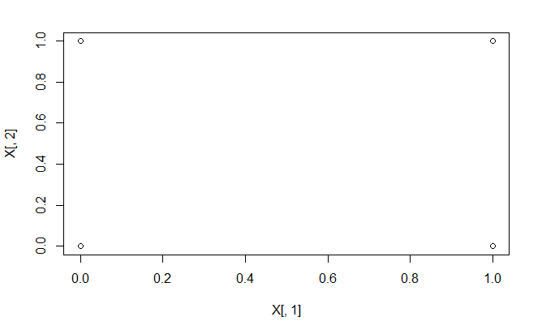

```r
plot(X[,1],X[,2])
```

```r
Z = t(t(X) / colMeans(X))
print(Z)
```

```
     [,1] [,2] [,3]      [,4]
[1,]    2    0  1.2 0.6666667
[2,]    0    3  0.8 1.3333333
[3,]    2    3  1.2 0.6666667
[4,]    0    0  0.8 1.3333333
[5,]    2    0  1.2 0.6666667
[6,]    0    0  0.8 1.3333333
```

```r
Z_transpose = t(Z)
print(Z_transpose)
```

```
          [,1]     [,2]      [,3]     [,4]      [,5]     [,6]
[1,] 2.0000000 0.000000 2.0000000 0.000000 2.0000000 0.000000
[2,] 0.0000000 3.000000 3.0000000 0.000000 0.0000000 0.000000
[3,] 1.2000000 0.800000 1.2000000 0.800000 1.2000000 0.800000
[4,] 0.6666667 1.333333 0.6666667 1.333333 0.6666667 1.333333
```

Take the matrix **Z**, transpose it, and multiply the transposed matrix by **Z**. (Writing this out mathematically, we would write this as **Z<sup>T</sup>Z**.) The resulting matrix is the covariance matrix of **Z**, up to a constant.

```r
Z_cov = t(Z) %*% Z
print(Z_cov)
```

```
     [,1] [,2] [,3]     [,4]
[1,] 12.0    6 7.20 4.000000
[2,]  6.0   18 6.00 6.000000
[3,]  7.2    6 6.24 5.600000
[4,]  4.0    6 5.60 6.666667
```

(This is probably the toughest step to follow—stick with me here.) Calculate the eigenvectors and their corresponding eigenvalues of **Z<sup>T</sup>Z**. This is quite easily done in most computing packages—in fact, the eigendecomposition of **Z<sup>T</sup>Z** is where we decompose **Z<sup>T</sup>Z** into **PDP<sup>-1</sup>**, where **P** is the matrix of eigenvectors and **D** is the diagonal matrix with eigenvalues on the diagonal and values of zero everywhere else. The eigenvalues on the diagonal of **D** will be associated with the corresponding column in **P**—that is, the first element of **D** is **$\lambda_1$** and the corresponding eigenvector is the first column of **P**. This holds for all elements in **D** and their corresponding eigenvectors in **P**. We will always be able to calculate **PDP<sup>-1</sup>** in this fashion. (Bonus: for those interested, we can always calculate **PDP<sup>-1</sup>** in this fashion because **Z<sup>T</sup>Z** is a symmetric, positive semidefinite matrix.)

Take the eigenvalues **$\lambda_1$**, **$\lambda_2$**, …, **$\lambda_P$** and sort them from largest to smallest. In doing so, sort the eigenvectors in **P** accordingly. (For example, if **$\lambda_2$** is the largest eigenvalue, then take the second column of **P** and place it in the first column position.) Depending on the computing package, this may be done automatically. Call this sorted matrix of eigenvectors **P***. (The columns of **P*** should be the same as the columns of **P**, but perhaps in a different order.) Note that these eigenvectors are independent of one another.

```r
E = eigen(Z_cov)
print(E)
```

```
$values
[1] 2.935361e+01 9.256943e+00 4.296113e+00 1.030686e-15

$vectors
           [,1]        [,2]       [,3]          [,4]
[1,] -0.4897534 -0.65769332 -0.4715061  3.244428e-01
[2,] -0.6726036  0.69089534 -0.2650811  2.775558e-16
[3,] -0.4160608 -0.29532192  0.2859784 -8.111071e-01
[4,] -0.3669324 -0.05374098  0.7909680  4.866643e-01
```

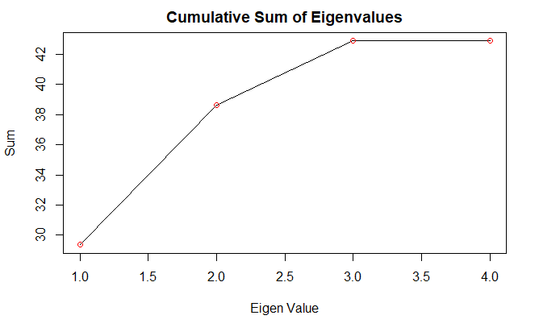

```r
plot(cumsum(E$values),
     type='l',
     xlab='Eigen Value',
     ylab='Sum',
     main='Cumulative Sum of Eigenvalues')
lines(cumsum(E$values), type='p', col='red')
```

```r
Z_star = Z %*% E$vectors
print(Z_star)
```

```
           [,1]       [,2]       [,3]          [,4]
[1,] -1.7234013 -1.7056003 -0.0725261 -1.110223e-16
[2,] -2.8399028  1.7647738  0.4881633  1.332268e-15
[3,] -3.7412122  0.3670857 -0.8677695  6.661338e-16
[4,] -0.8220919 -0.3079122  1.2834067  4.440892e-16
[5,] -1.7234013 -1.7056003 -0.0725261 -1.110223e-16
[6,] -0.8220919 -0.3079122  1.2834067  4.440892e-16
```

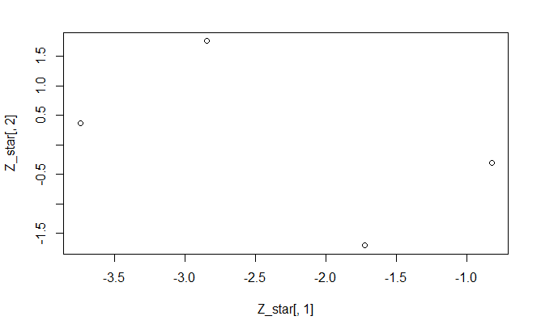

```r
plot(Z_star[,1],Z_star[,2])
```